# Gene-wise testing in depth, including multiple testing

https://compbiocore.github.io/cbc-workshop-directory/

**Abstract**

This session starts with some brief theory relevant to RNA-seq differential expression analysis, including model formulae, design matrices, generalized linear models, sampling, blocking, and stratification. It briefly summarizes the main approaches to RNA quantification, and to differential expression analysis in Bioconductor, then covers a workflow for differential expression hypothesis testing, visualization, and batch correction.

# Review - Model formulae

[Model formulae tutorial](http://ww2.coastal.edu/kingw/statistics/R-tutorials/formulae.html)

- many regression functions in R use a "model formula" interface.
- The formula determines the model that will be built (and tested) by the R procedure. The basic format is:

`> response variable ~ explanatory variables`

- The tilde means "is modeled by" or "is modeled as a function of."

## Essential model formulae terminology

| symbol | example | meaning |
| --- | --- | --- |
| + | + x | include this variable |
| - | - x | delete this variable |
| : | x : z | include the interaction |
| * | x * z | include these variables and their interactions |
| ^ | (u + v + w)^3 | include these variables and all interactions up to three way |
| 1 | -1 | intercept: delete the intercept |

Note: order generally doesn't matter (u+v OR v+u)

*Examples*: `~treatment`, `~treatment + time`, `~treatment * time`

# The Design Matrix

## The Design Matrix

Use an example of a multiple linear regression model:

$y_i = \beta_0 + \beta_1 x_{1i} + \beta_2 x_{2i} + ... + \beta_p x_{pi} + \epsilon_i$

- $x_{ji}$ is the value of predictor $x_j$ for observation $i$

## The Design Matrix

Matrix notation for the multiple linear regression model:

$$ \, \begin{pmatrix} Y_1\\ Y_2\\ \vdots\\ Y_N \end{pmatrix} = \begin{pmatrix} 1&x_1\\ 1&x_2\\ \vdots\\ 1&x_N \end{pmatrix} \begin{pmatrix} \beta_0\\ \beta_1 \end{pmatrix} + \begin{pmatrix} \varepsilon_1\\ \varepsilon_2\\ \vdots\\ \varepsilon_N \end{pmatrix} $$

or simply:

$$ \mathbf{Y}=\mathbf{X}\boldsymbol{\beta}+\boldsymbol{\varepsilon} $$

- The design matrix is $\mathbf{X}$
  - which the computer will take as a given when solving for $\boldsymbol{\beta}$ by minimizing the sum of squares of residuals $\boldsymbol{\varepsilon}$.

There are multiple possible and reasonable design matrices for a given study design

- the model formula encodes a default model matrix, e.g.:

```r
group <- factor( c(1, 1, 2, 2) )
model.matrix(~ group)
```

|  | (Intercept) | group2 |
| --- | --- | --- |
| 1 | 1 | 0 |
| 2 | 1 | 0 |
| 3 | 1 | 1 |
| 4 | 1 | 1 |

What if we forgot to code group as a factor?

```r
group <- c(1, 1, 2, 2)
model.matrix(~ group)
```

|  | (Intercept) | group |
| --- | --- | --- |
| 1 | 1 | 1 |
| 2 | 1 | 1 |
| 3 | 1 | 2 |
| 4 | 1 | 2 |

Here is an example again of a single predictor, but with more groups

```r
group <- factor(c(1,1,2,2,3,3))
model.matrix(~ group)
```

|  | (Intercept) | group2 | group3 |
| --- | --- | --- | --- |
| 1 | 1 | 0 | 0 |
| 2 | 1 | 0 | 0 |
| 3 | 1 | 1 | 0 |
| 4 | 1 | 1 | 0 |
| 5 | 1 | 0 | 1 |
| 6 | 1 | 0 | 1 |

The *baseline* group is the one that other groups are contrasted against. You can change the baseline group:

```r
group <- factor(c(1,1,2,2,3,3))
group <- relevel(x=group, ref=3)
model.matrix(~ group)
```

|  | (Intercept) | group1 | group2 |
| --- | --- | --- | --- |
| 1 | 1 | 1 | 0 |
| 2 | 1 | 1 | 0 |
| 3 | 1 | 0 | 1 |
| 4 | 1 | 0 | 1 |
| 5 | 1 | 0 | 0 |
| 6 | 1 | 0 | 0 |

The model matrix can represent multiple predictors, ie multiple (linear/log-linear/logistic) regression:

```r
diet <- factor(c(1,1,1,1,2,2,2,2))
sex <- factor(c("f","f","m","m","f","f","m","m"))
model.matrix(~ diet + sex)
```

|  | (Intercept) | diet2 | sexm |
| --- | --- | --- | --- |
| 1 | 1 | 0 | 0 |
| 2 | 1 | 0 | 0 |
| 3 | 1 | 0 | 1 |
| 4 | 1 | 0 | 1 |
| 5 | 1 | 1 | 0 |
| 6 | 1 | 1 | 0 |
| 7 | 1 | 1 | 1 |
| 8 | 1 | 1 | 1 |

And interaction terms:

```r
model.matrix(~ diet + sex + diet:sex)
```

|  | (Intercept) | diet2 | sexm | diet2:sexm |
| --- | --- | --- | --- | --- |
| 1 | 1 | 0 | 0 | 0 |
| 2 | 1 | 0 | 0 | 0 |
| 3 | 1 | 0 | 1 | 0 |
| 4 | 1 | 0 | 1 | 0 |
| 5 | 1 | 1 | 0 | 0 |
| 6 | 1 | 1 | 0 | 0 |
| 7 | 1 | 1 | 1 | 1 |
| 8 | 1 | 1 | 1 | 1 |

# Experimental Design - Blocking and Stratification

Blocking and stratification are related concepts that group more similar records together.

## Blocking in experimental design

- The differences between the "blocks" of individuals is "nuisance" variability that we want to control

[figure not shown]

- blocking is typical in biology experiments to:
  - apply an experimental randomization to more homogeneous "blocks" of individuals
  - assign treated and control specimens, or case & control specimens, equally and randomly to batches (really the same as above)
- blocks are normally included as a factor in regression analysis
  - can adjust for nuisance variables afterwards, but *include in experimental design wherever possible*

# Differential expression analysis

In the first period we counted the fragments which overlap the genes in the gene model we specified. From the summarized and annotated count matrix we imported, we could use a variety of Bioconductor packages for exploration and differential expression of the count data, including:

- DESeq2
- edgeR
- limma (use Voom method for RNA-seq)

[Schurch *et al.* 2016](https://www.ncbi.nlm.nih.gov/pmc/articles/pmid/27022035/) compared performance of different statistical methods for RNA-seq using a large number of biological replicates and can help users to decide which tools make sense to use, and how many biological replicates are necessary to obtain a certain sensitivity.

## Comparison of edgeR / DESeq2 / limma-voom

All excellent, well-documented packages, implementing similar key features:

- Empirical Bayes "regularization" or "shrinkage" of expression variance
  - borrows prior expectation for variance from all genes, reduces false positives in small samples
- Use of model formula, model matrices, and contrasts for flexible differential expression analysis
- Reporting of log fold-change and False Discovery Rate

Some ways they differ are:

- Error terms used (DESeq2 and edgeR use log-linear Generalized Linear Model with negative binomial error term, limma-voom uses linear regression on transformed counts)
- DESeq2 "automagically" handles independent filtering, using Independent Hypothesis Weighting ([IHW package](http://www.bioconductor.org/packages/IHW))
- Speed (limma-voom is much faster and should definitely be used if you have hundreds of samples)
- Approaches to hierarchical modeling, e.g. samples nested within groups
  - limma-voom has a built-in feature for sample correlations (called *duplicateCorrelation*)
- Re-use of core Bioconductor structures (DESeq2 extends *SummarizedExperiment*, edgeR and limma create their own)

DEseq is generally a practical and simple pipeline to run. However, for large datasets, especially if doing permutations for gene set enrichment analysis, limma with its voom method is far more practical. It is worth noting that for large sample size, it hardly matters which error model you use, owing to the Central Limit Theorem.

We will continue using DESeq2, starting from the *SummarizedExperiment* object.

## Running the differential expression pipeline

As we have already specified an experimental design when we created the *DESeqDataSet*, we can run the differential expression pipeline on the raw counts with a single call to the function *DESeq*:

```r
suppressPackageStartupMessages({
    library(DESeq2)
    library(airway)
    library('org.Hs.eg.db')
    library(enrichplot)
})
data(airway)
dds <- DESeqDataSet(airway, design = ~ cell + dex)
dds <- DESeq(dds)
```

This function will print out a message for the various steps it performs. These are described in more detail in the manual page for *DESeq*, which can be accessed by typing `?DESeq`. Briefly these are: the estimation of size factors (controlling for differences in the sequencing depth of the samples), the estimation of dispersion values for each gene, and fitting a generalized linear model (GLM).

A *DESeqDataSet* is returned that contains all the fitted parameters within it, and the following section describes how to extract out results tables of interest from this object.

## Building the results table

Calling `results` without any arguments will extract the estimated log2 fold changes and p-values **for the last variable in the design formula**. If there are more than 2 levels for this variable, `results` will extract the results table for a comparison of the last level over the first level.

```r
res <- results(dds)
res
```

```
log2 fold change (MLE): dex untrt vs trt
Wald test p-value: dex untrt vs trt
DataFrame with 64102 rows and 6 columns
                        baseMean      log2FoldChange             lfcSE
                       <numeric>           <numeric>         <numeric>
ENSG00000000003 708.602169691234   0.381253982523022 0.100654411871053
ENSG00000000005                0                  NA                NA
ENSG00000000419 520.297900552084  -0.206812601085038 0.112218646511604
ENSG00000000457 237.163036796015 -0.0379204312050627 0.143444654935652
ENSG00000000460 57.9326331250967  0.0881681758710969 0.287141822932241
...                          ...                 ...               ...
LRG_94                         0                  NA                NA
LRG_96                         0                  NA                NA
LRG_97                         0                  NA                NA
LRG_98                         0                  NA                NA
LRG_99                         0                  NA                NA
                              stat               pvalue                padj
                         <numeric>            <numeric>           <numeric>
ENSG00000000003   3.78775232437345 0.000152016273165534 0.00128362968272985
ENSG00000000005                 NA                   NA                  NA
ENSG00000000419  -1.84294328539822    0.065337291520207   0.196546085687684
ENSG00000000457 -0.264355832722198    0.791505741610679   0.911459479588999
ENSG00000000460    0.3070544547316    0.758801923975876   0.895032784967096
...                            ...                  ...                 ...
LRG_94                          NA                   NA                  NA
LRG_96                          NA                   NA                  NA
LRG_97                          NA                   NA                  NA
LRG_98                          NA                   NA                  NA
LRG_99                          NA                   NA                  NA
```

**Note, importantly, that there are some rows that are composed primarily of NAs - that is because we are running DESeq on the untransformed data, not the data we manipulated for exploratory data analysis in our first workshop. These NA rows are generated when the total counts for a gene are very low as a way of ignoring them in later stages of the analysis, in a manner analogous to our manual filtering from Workshop 1.**

```r
res.specific <- results(dds, contrast=c("dex","trt","untrt"))
res.specific
```

```
log2 fold change (MLE): dex trt vs untrt
Wald test p-value: dex trt vs untrt
DataFrame with 64102 rows and 6 columns
                        baseMean      log2FoldChange             lfcSE
                       <numeric>           <numeric>         <numeric>
ENSG00000000003 708.602169691234  -0.381253982523022 0.100654411871053
ENSG00000000005                0                  NA                NA
ENSG00000000419 520.297900552084   0.206812601085038 0.112218646511604
ENSG00000000457 237.163036796015  0.0379204312050627 0.143444654935652
ENSG00000000460 57.9326331250967 -0.0881681758710969 0.287141822932241
...                          ...                 ...               ...
LRG_94                         0                  NA                NA
LRG_96                         0                  NA                NA
LRG_97                         0                  NA                NA
LRG_98                         0                  NA                NA
LRG_99                         0                  NA                NA
                             stat               pvalue                padj
                        <numeric>            <numeric>           <numeric>
ENSG00000000003 -3.78775232437345 0.000152016273165534 0.00128362968272985
ENSG00000000005                NA                   NA                  NA
ENSG00000000419  1.84294328539822    0.065337291520207   0.196546085687684
ENSG00000000457 0.264355832722198    0.791505741610679   0.911459479588999
ENSG00000000460  -0.3070544547316    0.758801923975876   0.895032784967096
...                           ...                  ...                 ...
LRG_94                         NA                   NA                  NA
LRG_96                         NA                   NA                  NA
LRG_97                         NA                   NA                  NA
LRG_98                         NA                   NA                  NA
LRG_99                         NA                   NA                  NA
```

```r
res
```

```
log2 fold change (MLE): dex untrt vs trt
Wald test p-value: dex untrt vs trt
DataFrame with 64102 rows and 6 columns
                        baseMean      log2FoldChange             lfcSE
                       <numeric>           <numeric>         <numeric>
ENSG00000000003 708.602169691234   0.381253982523022 0.100654411871053
ENSG00000000005                0                  NA                NA
ENSG00000000419 520.297900552084  -0.206812601085038 0.112218646511604
ENSG00000000457 237.163036796015 -0.0379204312050627 0.143444654935652
ENSG00000000460 57.9326331250967  0.0881681758710969 0.287141822932241
...                          ...                 ...               ...
LRG_94                         0                  NA                NA
LRG_96                         0                  NA                NA
LRG_97                         0                  NA                NA
LRG_98                         0                  NA                NA
LRG_99                         0                  NA                NA
                              stat               pvalue                padj
                         <numeric>            <numeric>           <numeric>
ENSG00000000003   3.78775232437345 0.000152016273165534 0.00128362968272985
ENSG00000000005                 NA                   NA                  NA
ENSG00000000419  -1.84294328539822    0.065337291520207   0.196546085687684
ENSG00000000457 -0.264355832722198    0.791505741610679   0.911459479588999
ENSG00000000460    0.3070544547316    0.758801923975876   0.895032784967096
...                            ...                  ...                 ...
LRG_94                          NA                   NA                  NA
LRG_96                          NA                   NA                  NA
LRG_97                          NA                   NA                  NA
LRG_98                          NA                   NA                  NA
LRG_99                          NA                   NA                  NA
```

As `res` is a *DataFrame* object, it carries metadata with information on the meaning of the columns:

```r
mcols(res, use.names = TRUE)
```

```
DataFrame with 6 rows and 2 columns
                       type                               description
                <character>                               <character>
baseMean       intermediate mean of normalized counts for all samples
log2FoldChange      results  log2 fold change (MLE): dex untrt vs trt
lfcSE               results          standard error: dex untrt vs trt
stat                results          Wald statistic: dex untrt vs trt
pvalue              results       Wald test p-value: dex untrt vs trt
padj                results                      BH adjusted p-values
```

The column `log2FoldChange` is the effect size estimate. It tells us how much the gene's expression seems to have changed due to treatment with dexamethasone in comparison to untreated samples. This value is reported on a logarithmic scale to base 2: for example, a log2 fold change of 1.5 means that the gene's expression is increased by a multiplicative factor of $2^{1.5} \approx 2.82$.

Of course, this estimate has an uncertainty associated with it, which is available in the column `lfcSE`, the *standard error estimate* for the log2 fold change estimate. We can also express the uncertainty of a particular effect size estimate as the result of a statistical test. **The purpose of a test for differential expression is to test whether the data provides sufficient evidence to conclude that this value is really different from zero for a reason other than random chance**. *DESeq2* performs, for each gene, a *hypothesis test* to see whether evidence is sufficient to decide against the *null hypothesis* that there is zero effect of the treatment on the gene and that the observed difference between treatment and control was merely caused by experimental variability (i.e., the type of variability that you can expect between different samples in the same treatment group). As usual in statistics, the result of this test is reported as a p-value, and it is found in the column `pvalue`. Remember that a p-value indicates the probability that a fold change as strong as the observed one, or even stronger, would be seen under the situation described by the null hypothesis.

We can also summarize the results with the following line of code, which reports some additional information, that will be covered in later sections.

```r
summary(res)
```

```
out of 33469 with nonzero total read count
adjusted p-value < 0.1
LFC > 0 (up)       : 2215, 6.6%
LFC < 0 (down)     : 2604, 7.8%
outliers [1]       : 0, 0%
low counts [2]     : 15441, 46%
(mean count < 5)
[1] see 'cooksCutoff' argument of ?results
[2] see 'independentFiltering' argument of ?results
```

First, note that `summary` describes only those genes with a nonzero read count - i.e. it ignores the NA-only rows that we noticed when viewing the top of the results table. R has a convenient way to detect and ignore NAs that Bioconductor is using internally; we will discuss this method, and how to invoke it manually, a bit later.

Next, note that there are many genes with differential expression due to dexamethasone treatment at the FDR level of 10%. This makes sense, as the smooth muscle cells of the airway are known to react to glucocorticoid steroids. However, there are two ways to be more strict about which set of genes are considered significant:

- lower the false discovery rate threshold (the threshold on `padj` in the results table)
- raise the log2 fold change threshold from 0 using the `lfcThreshold` argument of *results*

If we lower the false discovery rate threshold, we should also inform the `results()` function about it, so that the function can use this threshold for the optimal independent filtering that it performs:

## A Note on Statistical Terminology

- For large samples, violations of distributional assumptions have diminishing importance
- *Standard Error* is the standard deviation of a normally distributed sampling distribution
- The null hypothesis is an assumption about the form of a sampling distribution

We have thus far defined the p-value with respect to the null hypothesis, but have yet to state what the null hypothesis actually means. Generally, in a biological experiment, the null hypothesis is that there is no difference between two (or more) different groups according so some metric being studied e.g. gene expression. The alternative hypothesis is that there is some difference. To determine which of these hypotheses is more likely to be correct, we calculate a p-value.

**p-value:** the probability of getting a result at least as extreme as the one observed *given* that the null hypothesis is true.

Thus, a low p-value means it's unlikely that you'd see what you're seeing if the null hypothesis is true, providing evidence that the null hypothesis is not true - in classical statistics, if that probability is lower than .05 (5%), we *reject the null hypothesis*. Note that this is not strictly identical to as *accepting the alternative hypothesis*, but with the null rejected, we only have the alternative hypothesis left (under this framework).

## Multiple testing

```r
sum(res$pvalue < 0.05)
```

<NA>

This code, though written correctly, yields a result of NA, meaning the data is missing. Why is that?

```r
table(is.na(res$pvalue))
```

```
FALSE  TRUE
33469 30633
```

Here, we tabulate the occurrence of NAs within our data. As can be seen, there is missingness in this data. By default, R uses all data in performing its calculations, so the presence of even one NA will lead to a result of NA. However, as alluded to before, there is a simple way to have R ignore NAs when running a calculation.

**Important Note:** `na.rm = TRUE` is an argument that tells R to ignore missing values when performing a given operation - since NA is not a valid number, most calculations involving **any** NA values returns NA. High-dimensional data analysis usually does include some missing values, so this argument is important.

The command means "remove NAs", but it doesn't physically remove them from the actual data object - it just temporarily removes them for the purposes of the single command it's invoked upon. Thus, it's easy to keep track of the NAs in the original data set since they're not modified in any way.

```r
sum(res$pvalue < 0.05, na.rm=TRUE)
```

5677

With the missing values omitted, the same command runs to completion and yields a sensible (but extreme) result.

```r
sum(!is.na(res$pvalue))
```

33469

Now, assume for a moment that the null hypothesis is true for all genes, i.e., no gene is affected by the treatment with dexamethasone.

**Essentially, we are setting ourselves up to fix the rate at which false positives will be included in the gene list.**

The FDR is a useful statistic for many high-throughput experiments, as we are often interested in reporting or focusing on a set of interesting genes, and we would like to put an upper bound on the percent of false positives in this set.

Hence, if we consider a fraction of 10% false positives acceptable, we can consider all genes with an adjusted *p* value below 10% = 0.1 as significant. How many such genes are there?

```r
sum(res$padj < 0.1, na.rm=TRUE)
```

4819

```r
## [1] 4819
```

```r
res.05 <- results(dds, alpha = 0.05)
table(res.05$padj < 0.05)
```

```
FALSE  TRUE
12765  4028
```

If we want to raise the log2 fold change threshold, so that we test for genes that show more substantial changes due to treatment, we simply supply a value on the log2 scale. For example, by specifying `lfcThreshold = 1`, we test for genes that show significant effects of treatment on gene counts more than doubling or less than halving, because $2^1 = 2$.

```r
resLFC1 <- results(dds, lfcThreshold=1)
table(resLFC1$padj < 0.1)
```

```
FALSE  TRUE
20259   240
```

If we plot the distribution of adjusted p-values (i.e. q-values, i.e. FDR), we can see that the overwhelming majority of genes are found at a value of 1 - that is to say, they are almost surely not significant. Zooming in on the lowest values, we can see the distribution close to 0 - that is to say, the genes that are potentially significant, depending on the cutoff we use.

We will formally define FDR in a few minutes. For now, just think of it as a substitute for the p-value.

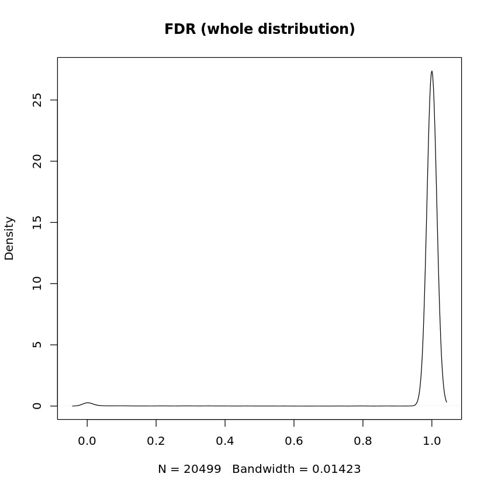

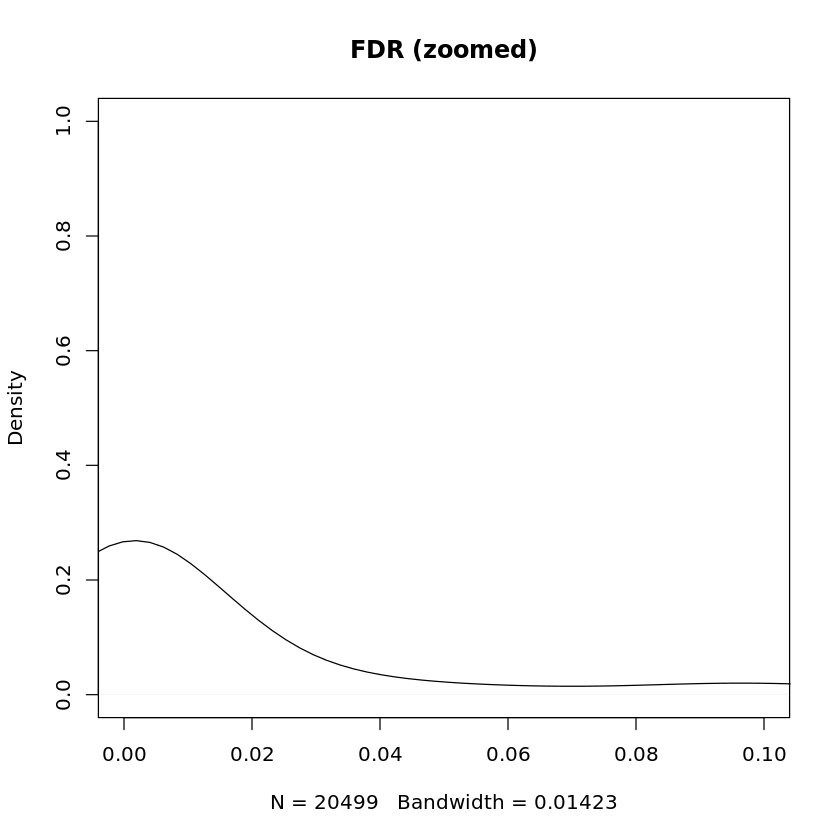

```r
plot(density(resLFC1$padj, na.rm=T), main = "FDR (whole distribution)")
plot(density(resLFC1$padj, na.rm=T), xlim = c(0, 0.1), ylim = c(0, 1), main = "FDR (zoomed)")
```

## Other comparisons

In general, the results for a comparison of any two levels of a variable can be extracted using the `contrast` argument to *results*. The user should specify three values: the name of the variable, the name of the level for the numerator, and the name of the level for the denominator. Here we extract results for the log2 of the fold change of one cell line over another.

We will explicitly specify which cell lines to compare since there are more than two levels:

```r
results(dds, contrast = c("cell", "N061011", "N61311"))
```

```
log2 fold change (MLE): cell N061011 vs N61311
Wald test p-value: cell N061011 vs N61311
DataFrame with 64102 rows and 6 columns
                        baseMean      log2FoldChange             lfcSE
                       <numeric>           <numeric>         <numeric>
ENSG00000000003 708.602169691234   0.306326362873039  0.14353084065546
ENSG00000000005                0                  NA                NA
ENSG00000000419 520.297900552084 -0.0540467039915908 0.159716051407156
ENSG00000000457 237.163036796015  0.0163084052792193 0.203025870489992
ENSG00000000460 57.9326331250967   0.279127022242881 0.400667153421976
...                          ...                 ...               ...
LRG_94                         0                  NA                NA
LRG_96                         0                  NA                NA
LRG_97                         0                  NA                NA
LRG_98                         0                  NA                NA
LRG_99                         0                  NA                NA
                              stat             pvalue              padj
                         <numeric>          <numeric>         <numeric>
ENSG00000000003   2.13421980582113 0.0328247921749011 0.220190430066927
ENSG00000000005                 NA                 NA                NA
ENSG00000000419 -0.338392437800834  0.735067472125772 0.939063374622145
ENSG00000000457 0.0803267349124514  0.935977395526993 0.990366971920045
ENSG00000000460  0.696655615163216  0.486018341867205 0.854831824849409
...                            ...                ...               ...
LRG_94                          NA                 NA                NA
LRG_96                          NA                 NA                NA
LRG_97                          NA                 NA                NA
LRG_98                          NA                 NA                NA
LRG_99                          NA                 NA                NA
```

There are additional ways to build results tables for certain comparisons after running *DESeq* once. If results for an interaction term are desired, the `name` argument of `results` should be used. Please see the help page for the `results` function for details on the additional ways to build results tables. In particular, the **Examples** section of the help page for `results` gives some pertinent examples.

We subset the results table to these genes and then sort it by the log2 fold change estimate to get the significant genes with the strongest downregulation:

```r
resSig <- subset(res, padj < 0.1)
head(resSig[ order(resSig$log2FoldChange), ])
```

```
log2 fold change (MLE): dex untrt vs trt
Wald test p-value: dex untrt vs trt
DataFrame with 6 rows and 6 columns
                        baseMean    log2FoldChange             lfcSE
                       <numeric>         <numeric>         <numeric>
ENSG00000179593 67.2430476358842 -9.50597481195291  1.05450324101422
ENSG00000109906 385.071028862516 -7.35262580898063 0.536388708511624
ENSG00000250978 56.3181939282226 -6.32738293366946 0.677797319853912
ENSG00000132518 5.65465445433956 -5.88511378994675  1.32404391875986
ENSG00000127954 286.384119280247 -5.20715842162318 0.493081792090907
ENSG00000249364 8.83906075961539 -5.09810711398969  1.15961469145613
                             stat               pvalue                 padj
                        <numeric>            <numeric>            <numeric>
ENSG00000179593 -9.01464731659819 1.97504932845722e-19  1.2537390596277e-17
ENSG00000109906 -13.7076446470746 9.13762134001944e-43  2.2566169522996e-40
ENSG00000250978 -9.33521385866976 1.00787575009327e-20 7.21031112011168e-19
ENSG00000132518 -4.44480255266678 8.79726245592064e-06 0.000100061228741538
ENSG00000127954 -10.5604354189237 4.54548441119938e-26 5.05839462747545e-24
ENSG00000249364 -4.39638023867047 1.10071046444068e-05 0.000122491408968745
```

...and with the strongest upregulation:

```r
head(resSig[ order(resSig$log2FoldChange, decreasing = TRUE), ])
```

```
log2 fold change (MLE): dex untrt vs trt
Wald test p-value: dex untrt vs trt
DataFrame with 6 rows and 6 columns
                        baseMean   log2FoldChange             lfcSE
                       <numeric>        <numeric>         <numeric>
ENSG00000128285 6.62474139908411 5.32590370300279  1.25781474332103
ENSG00000267339 26.2335725682209 4.61155177220382 0.673094224246759
ENSG00000019186 14.0876049307722 4.32590590658271 0.857766868062707
ENSG00000183454 5.80417114112773  4.2640756102538  1.16687582780694
ENSG00000146006 46.8075965458274 4.21185080264219 0.528851581079443
ENSG00000141469 53.4365283575179   4.124796479177  1.12979869831239
                            stat               pvalue                 padj
                       <numeric>            <numeric>            <numeric>
ENSG00000128285 4.23425129279429 2.29314410042223e-05  0.00023800116201734
ENSG00000267339 6.85127223809487 7.31960666187703e-12   2.052221911358e-10
ENSG00000019186 5.04321869688545 4.57765545649035e-07 6.61715662917313e-06
ENSG00000183454 3.65426681112062 0.000257917952003664  0.00205109658489414
ENSG00000146006  7.9641452409868 1.66369754714747e-15 7.15578687805286e-14
ENSG00000141469 3.65091275581954 0.000261309999768389  0.00207345804393685
```

# Diagnostic plots

## MA-plot

An *MA-plot* ([Dudoit et al., Statistica Sinica, 2002](http://wwwf.imperial.ac.uk/~das01/BioinformaticsMSc/Papers/sinica.final.pdf)) provides a useful overview for the distribution of the estimated coefficients in the model, i.e. the comparisons of interest, across all genes. On the y-axis, the "M" stands for "minus" -- subtraction of log values is equivalent to the log of the ratio -- and on the x-axis, the "A" stands for "average". You may hear this plot also referred to as a "mean-difference plot", or a "Bland-Altman plot".

Before making the MA-plot, we use the `lfcShrink` function to shrink the log2 fold-changes for the comparison of dex treated vs untreated samples:

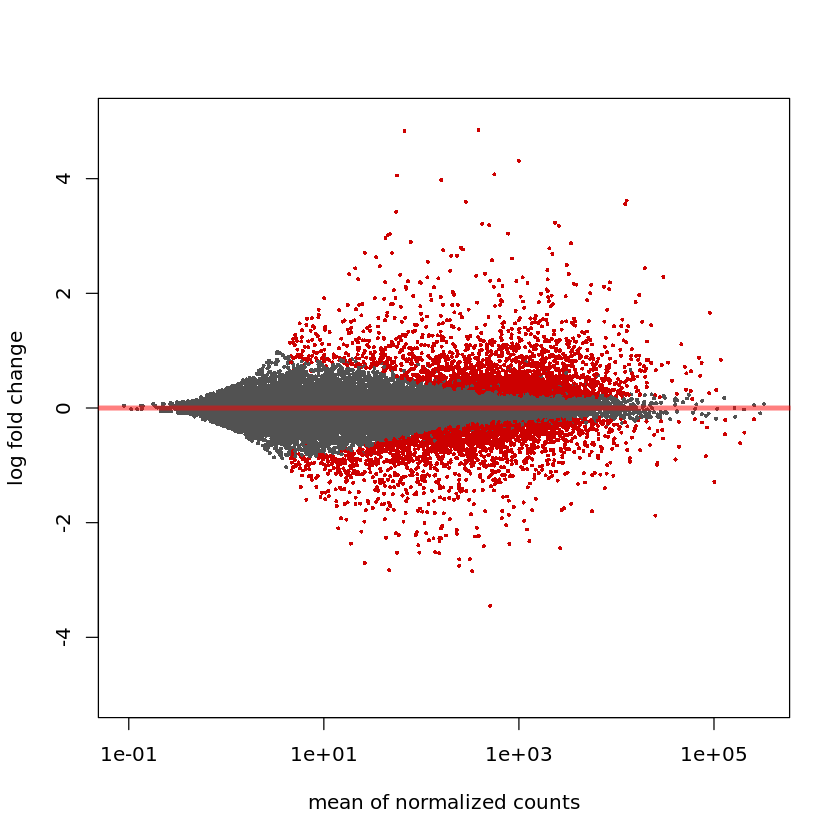

```r
res <- lfcShrink(dds, contrast=c("dex","trt","untrt"), res=res)
plotMA(res, ylim = c(-5, 5))
```

**An MA-plot of changes induced by treatment.** The log2 fold-change for a particular comparison is plotted on the y-axis and the average of the counts normalized by size factor is shown on the x-axis. Each gene is represented with a dot. Genes with an adjusted *p* value below a threshold (here 0.1, the default) are shown in red.

The *DESeq2* package uses a Bayesian procedure to moderate (or "shrink") log2 fold changes from genes with very low counts and highly variable counts, as can be seen by the narrowing of the vertical spread of points on the left side of the MA-plot. As shown above, the `lfcShrink` function performs this operation. For a detailed explanation of the rationale of moderated fold changes, please see the *DESeq2* paper ([Love and Huber, Genome Biology, 2014](http://wwwf.imperial.ac.uk/~das01/BioinformaticsMSc/Papers/sinica.final.pdf)).

If we had not used statistical moderation to shrink the noisy log2 fold changes, we would have instead seen the following plot:

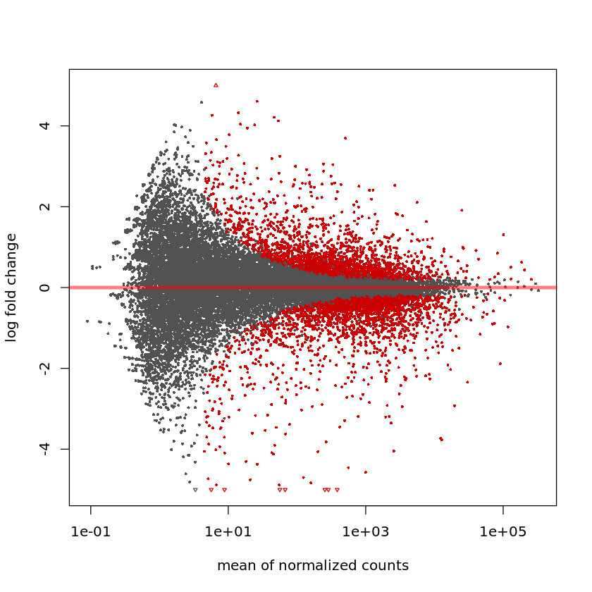

```r
res.noshr <- results(dds)
plotMA(res.noshr, ylim = c(-5, 5))
```

We can label individual points on the MA-plot as well. Here we use the `with` R function to plot a circle and text for a selected row of the results object. Within the `with` function, only the `baseMean` and `log2FoldChange` values for the selected rows of `res` are used.

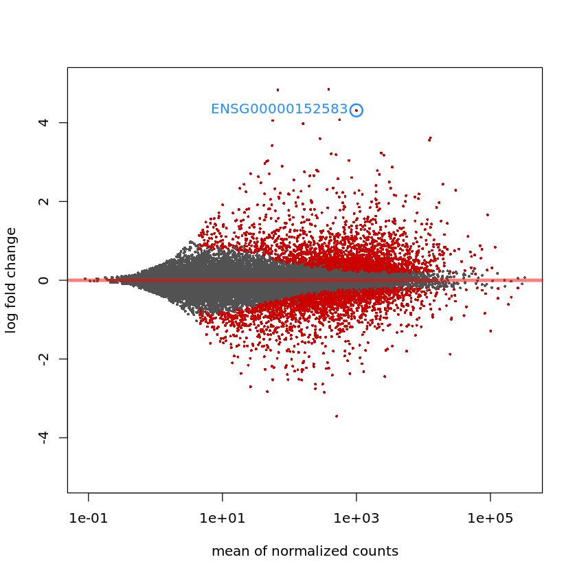

```r
plotMA(res, ylim = c(-5,5))
topGene <- rownames(res)[which.min(res$padj)]
with(res[topGene, ], {
  points(baseMean, log2FoldChange, col="dodgerblue", cex=2, lwd=2)
  text(baseMean, log2FoldChange, topGene, pos=2, col="dodgerblue")
})
```

Another useful diagnostic plot is the histogram of the p-values (figure below). This plot is best formed by excluding genes with very small counts, which otherwise generate spikes in the histogram.

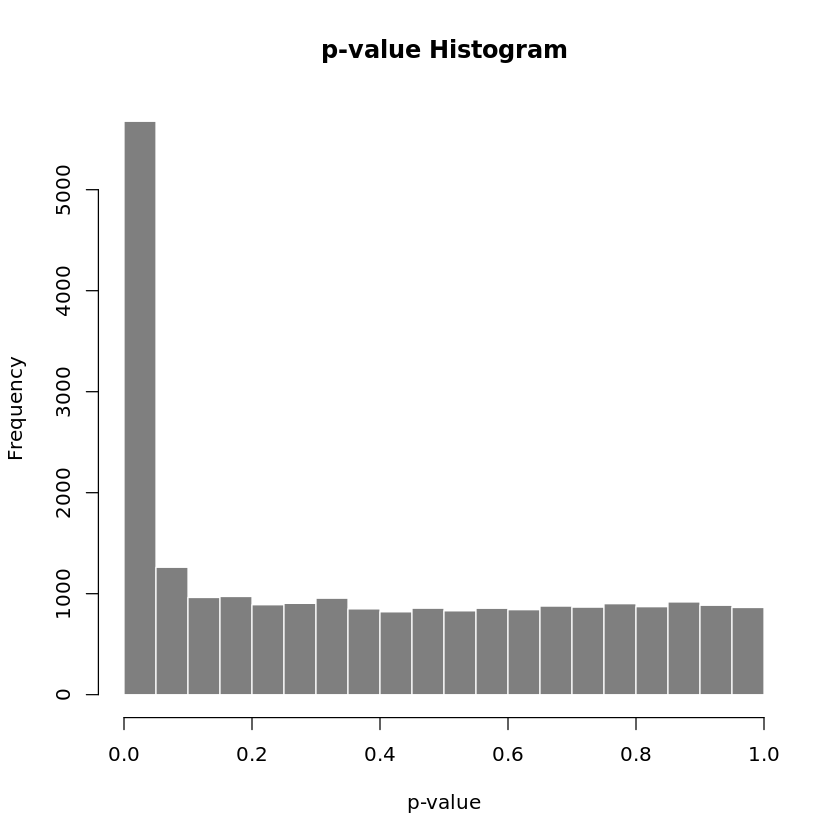

```r
hist(res$pvalue[res$baseMean > 1], breaks = 0:20/20,
     col = "grey50", border = "white", main = "p-value Histogram", xlab = "p-value")
```

**Histogram of *p* values for genes with mean normalized count larger than 1.**

## Volcano plot

A typical volcano plot is a scatterplot of $-log_{10}$(p-value) vs. $log_2$(fold-change). It allows you to visualize the difference in expression between groups against the statistical significance of that difference. Some things to look for:

- are diffentially expressed genes skewed towards up or down-regulation?
- are there a lot of significant but very low fold-change genes? This can result from a confounded batch effect.

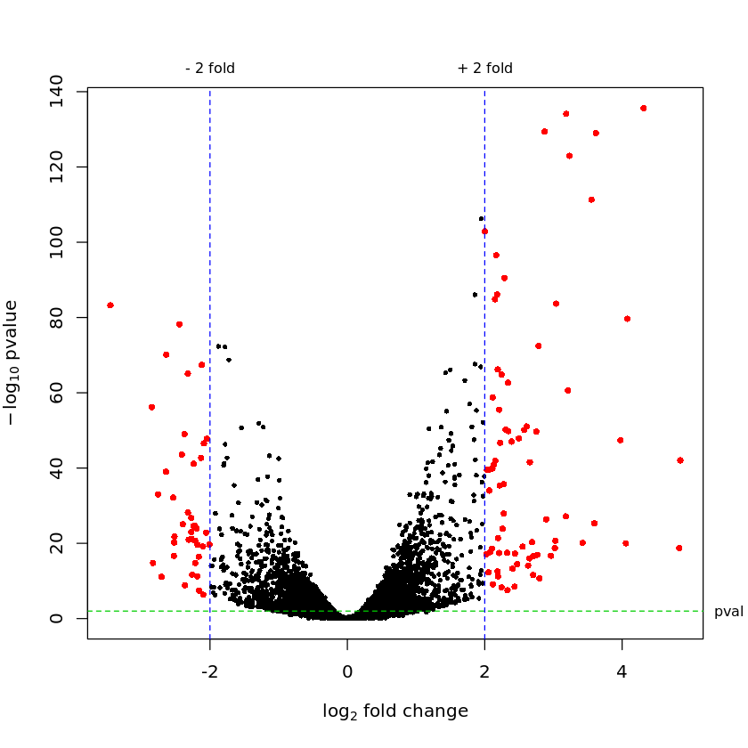

```r
volcanoPlot <- function(res, lfc=2, pval=0.01){
    tab = data.frame(logFC = res$log2FoldChange, negLogPval = -log10(res$pvalue))
    plot(tab, pch = 16, cex = 0.6, xlab = expression(log[2]~fold~change), ylab = expression(-log[10]~pvalue))
    signGenes = (abs(tab$logFC) > lfc & tab$negLogPval > -log10(pval))
    points(tab[signGenes, ], pch = 16, cex = 0.8, col = "red")
    abline(h = -log10(pval), col = "green3", lty = 2)
    abline(v = c(-lfc, lfc), col = "blue", lty = 2)
    mtext(paste("pval =", pval), side = 4, at = -log10(pval), cex = 0.8, line = 0.5, las = 1)
    mtext(c(paste("-", lfc, "fold"), paste("+", lfc, "fold")), side = 3, at = c(-lfc, lfc), cex = 0.8, line = 0.5)
}
volcanoPlot(res)
```

# Visualizing differential expression results

## A Note on Counts in DESeq2

When performing its analysis, DESeq2 performs count normaliziation to correct for factors such as library size. It does so in an attempt to abrogate the effects of count magnitude on differential expression status - otherwise, nonsignificant genes with very large counts would appear as false positives and significant genes with very small counts would appear as false negatives.

Common methods of normalization include TMM (Trimmed Mean of M-Values), RLE (Relative Log Expression), and MRN (Median Ratio Normalization). TMM and RLE, used by edgeR and DESeq2, yield very similar results.

When obtaining a result from DESeq highlighting a list of genes, people will often look back at their original count table using a program like Excel and examine the counts tabulated therein. **Doing so is inadvisable and misleading**, as these non-normalized counts are not proper indicators of significance.

## Counts plot

A quick way to visualize the counts for a particular gene is to use the *plotCounts* function that takes as arguments the *DESeqDataSet*, a gene name, and the group over which to plot the counts (figure below).

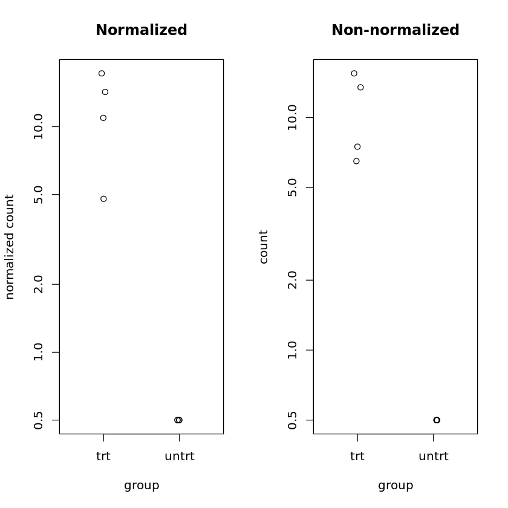

```r
par(mfrow=c(1,2))
topGene <- rownames(res)[which.min(res$padj)]
plotCounts(dds, gene = "ENSG00000132518", intgroup=c("dex"), main = "Normalized")
plotCounts(dds, gene = "ENSG00000132518", intgroup=c("dex"), normalized = F, main = "Non-normalized")
```

**Normalized counts for a single gene over treatment group.**

# Ontology Analysis

Now that we have retrieved a list of differentially expressed genes, we will generally proceed to use this list to draw biological insight via "gene ontology" analysis - basically, using lists of terms associated with genes to figure out which pathways are being modified in a cohesive manner.

Simply put, the general principle is to test whether known biological functions or processes are over-represented (= enriched) in an experimentally-derived gene list, e.g. a list of differentially expressed (DE) genes computed by DEseq - see [Goeman and Buehlmann, 2007](https://doi.org/10.1093/bioinformatics/btm051) for a critical review.

Example: Transcriptomic study, in which 12,671 genes have been tested for differential expression between two sample conditions and 529 genes were found DE.

Among the DE genes, 28 are annotated to a specific functional gene set, which contains in total 170 genes. This setup corresponds to a 2x2 contingency table:

```r
deTable <-
     matrix(c(28, 142, 501, 12000),
            nrow = 2,
            dimnames = list(c("DE", "Not.DE"),
                            c("In.gene.set", "Not.in.gene.set")))
deTable
```

|  | In.gene.set | Not.in.gene.set |
| --- | --- | --- |
| DE | 28 | 501 |
| Not.DE | 142 | 12000 |

where the overlap of 28 genes can be assessed based on the [hypergeometric distribution](https://en.wikipedia.org/wiki/Hypergeometric_distribution). This corresponds to a one-sided version of Fisher's exact test, yielding here a significant enrichment.

```r
fisher.test(deTable, alternative = "greater")
```

```
	Fisher's Exact Test for Count Data

data:  deTable
p-value = 4.088e-10
alternative hypothesis: true odds ratio is greater than 1
95 percent confidence interval:
 3.226736      Inf
sample estimates:
odds ratio
  4.721744
```

Many genes fall into more than one category:

[figure not shown]

R will keep track of all the terms associated with a given gene depending on which database you use for your analysis. The most well-known databases are GO and KEGG, both of which are implemented in R. Today, we'll see an example using GO, as implemented in [the `goseq` package created by Jeff Leek](https://bioconductor.org/packages/release/bioc/html/goseq.html).

First, we will load the package and see what genomes it supports. Then, we'll format our data in the manner expected by the package.

```r
library(goseq)
```

```r
head(supportedGenomes())
```

|  | db | species | date | name | AvailableGeneIDs |
| --- | --- | --- | --- | --- | --- |
| 2 | hg19 | Human | Feb. 2009 | Genome Reference Consortium GRCh37 | ccdsGene,ensGene,exoniphy,geneSymbol,knownGene,nscanGene,refGene,xenoRefGene |
| 3 | hg18 | Human | Mar. 2006 | NCBI Build 36.1 | acembly,acescan,ccdsGene,ensGene,exoniphy,geneSymbol,geneid,genscan,knownGene,knownGeneOld3,refGene,sgpGene,sibGene,xenoRefGene |
| 4 | hg17 | Human | May 2004 | NCBI Build 35 | acembly,acescan,ccdsGene,ensGene,exoniphy,geneSymbol,geneid,genscan,knownGene,refGene,sgpGene,vegaGene,vegaPseudoGene,xenoRefGene |
| 5 | hg16 | Human | Jul. 2003 | NCBI Build 34 | acembly,ensGene,exoniphy,geneSymbol,geneid,genscan,knownGene,refGene,sgpGene |
| 19 | felCat3 | Cat | Mar. 2006 | Broad Institute Release 3 | ensGene,geneSymbol,geneid,genscan,nscanGene,refGene,sgpGene,xenoRefGene |
| 24 | panTro2 | Chimp | Mar. 2006 | CGSC Build 2.1 | ensGene,geneSymbol,genscan,nscanGene,refGene,xenoRefGene |

We take our list of genes, subset by adjusted p-value, and then remove the missing values.

```r
#test.ids <- rownames(resSig[ order(resSig$log2FoldChange, decreasing = TRUE), ])
#head(test.ids)

goseq.genes <- as.integer(res$padj < 0.1)
not.na <- !is.na(goseq.genes)
names(goseq.genes) <- rownames(res)
goseq.genes <- goseq.genes[not.na]
```

Next, we generate a "weighting function" by specifying which genome to use and by denoting what type of IDs our genes are listed using (Ensembl IDs):

```
Loading hg19 length data...
Warning message in pcls(G):
“initial point very close to some inequality constraints”
```

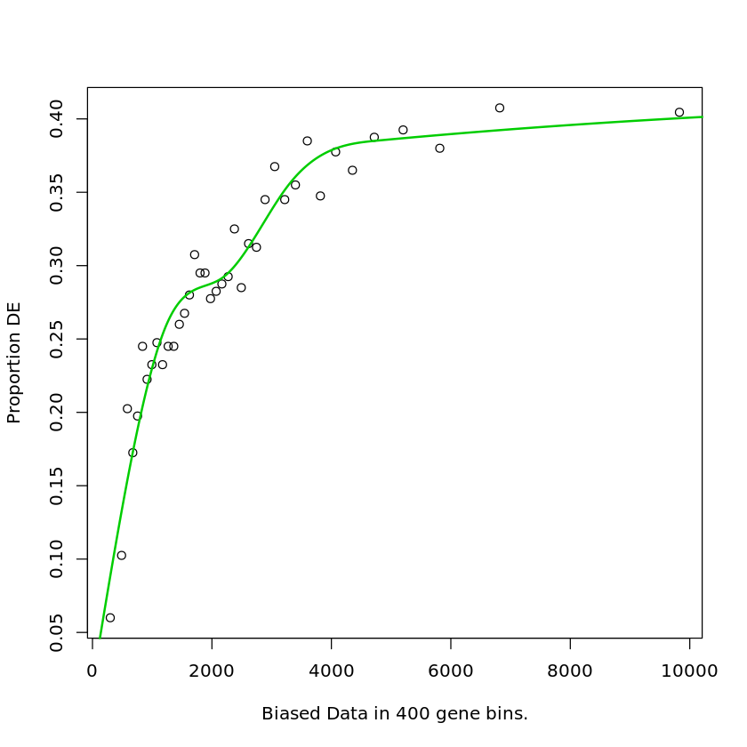

```r
pwf <- nullp(goseq.genes, "hg19", "ensGene")
```

```r
head(pwf)
```

|  | DEgenes | bias.data | pwf |
| --- | --- | --- | --- |
| ENSG00000000003 | 1 | 1563.5 | 0.2796184 |
| ENSG00000000419 | 0 | 1079.5 | 0.2415874 |
| ENSG00000000457 | 0 | 3128.5 | 0.3461814 |
| ENSG00000000460 | 0 | 3126.0 | 0.3460289 |
| ENSG00000000971 | 1 | 1597.0 | 0.2806996 |
| ENSG00000001036 | 1 | 1365.0 | 0.2698513 |

Finally, we run the `goseq` function, once again specifying the annotation and ID type

```r
go.wall <- goseq(pwf, "hg19", "ensGene")
```

```
Fetching GO annotations...
For 4786 genes, we could not find any categories. These genes will be excluded.
To force their use, please run with use_genes_without_cat=TRUE (see documentation).
This was the default behavior for version 1.15.1 and earlier.
Calculating the p-values...
```

```r
head(go.wall, 20)
```

|  | category | over_represented_pvalue | under_represented_pvalue | numDEInCat | numInCat | term | ontology |
| --- | --- | --- | --- | --- | --- | --- | --- |
| 2445 | GO:0005576 | 4.942419e-27 | 1 | 1218 | 3088 | extracellular region | CC |
| 12695 | GO:0048856 | 7.217521e-26 | 1 | 1585 | 3991 | anatomical structure development | BP |
| 12637 | GO:0048731 | 1.247622e-25 | 1 | 1324 | 3247 | system development | BP |
| 15915 | GO:0071944 | 1.255243e-25 | 1 | 1348 | 3310 | cell periphery | CC |
| 12519 | GO:0048513 | 1.219553e-24 | 1 | 969 | 2292 | animal organ development | BP |
| 8070 | GO:0032502 | 1.536548e-24 | 1 | 1683 | 4305 | developmental process | BP |
| 3512 | GO:0007275 | 1.562605e-24 | 1 | 1459 | 3647 | multicellular organism development | BP |
| 4342 | GO:0009653 | 1.662960e-24 | 1 | 836 | 1897 | anatomical structure morphogenesis | BP |
| 11112 | GO:0044421 | 2.242859e-24 | 1 | 1086 | 2746 | extracellular region part | CC |
| 2636 | GO:0005886 | 3.782718e-24 | 1 | 1310 | 3223 | plasma membrane | CC |
| 2474 | GO:0005615 | 8.774073e-24 | 1 | 1028 | 2598 | extracellular space | CC |
| 8069 | GO:0032501 | 9.777250e-24 | 1 | 1804 | 4679 | multicellular organismal process | BP |
| 12975 | GO:0050896 | 1.310667e-23 | 1 | 2235 | 6036 | response to stimulus | BP |
| 6763 | GO:0023052 | 4.211288e-23 | 1 | 1702 | 4394 | signaling | BP |
| 10130 | GO:0042221 | 1.010023e-22 | 1 | 1202 | 3025 | response to chemical | BP |
| 3426 | GO:0007154 | 1.111772e-22 | 1 | 1703 | 4408 | cell communication | BP |
| 3437 | GO:0007165 | 1.821805e-22 | 1 | 1573 | 4044 | signal transduction | BP |
| 13190 | GO:0051239 | 4.592070e-21 | 1 | 854 | 2021 | regulation of multicellular organismal process | BP |
| 10014 | GO:0040011 | 2.081204e-20 | 1 | 562 | 1239 | locomotion | BP |
| 9239 | GO:0035295 | 4.011613e-20 | 1 | 371 | 751 | tube development | BP |

As can be seen, however, these GO terms are often quite broad and may not be particularly informative in a given analysis. Thus, we will also take a look at another approach that specifically examines disease states and their associated pathologies. In doing so, we will create a variety of visualizations of these disease-related terms, most notably those included in [the 'enrichplot' package by Guangchuang Yu](https://bioconductor.org/packages/release/bioc/html/enrichplot.html).

However, this package does not allow us to use the raw Ensembl IDs that were accommodated by `goseq`. Thus, we must first discuss a common operation performed during the course of RNA-seq analysis - ID mapping, the process by which one type of ID is translated into another.

## ID Mapping

Before we perform our `enrichplot` ontology analysis, however, we need to be sure that our gene IDs are tabulated using the correct identification scheme. There are many different types of IDs that can be used in genomics, including the Ensembl ID, the Entrez ID, the gene symbol, and more. It is fundamental that we are aware of exactly what type of ID we are dealing with, as ontology analysis packages often require the IDs to be provided in a very specific manner.

```r
test.ids <- rownames(resSig[ order(resSig$log2FoldChange, decreasing = TRUE), ])
head(test.ids)
```

1. 'ENSG00000128285'

2. 'ENSG00000267339'

3. 'ENSG00000019186'

4. 'ENSG00000183454'

5. 'ENSG00000146006'

6. 'ENSG00000141469'

Looking at our IDs, we can see that they all follow a specific format - that is, ENSG*. These abbreviations mean "Ensembl Gene *", and are examples of Ensembl IDs. The enrichplot package requires us to have a list of IDs in Entrez format, the scheme used by NCBI, so we must first convert our Ensembl IDs to Entrez IDs. This process can be accomplished simply using the `mapIds` function. Note that in this function, the first ID argument is the ID type we want, while the second ID argument is the ID type we already have, which can be a bit confusing.

Also note the `org.Hs.eg.db` argument - that refers to the database being used internally to perform the mapping. Since human genes are well-characterized, this database is conveniently available as an R package that `mapIds` can directly interface with.

```r
#entrez.ids <- mapIds(org.Hs.eg.db, "ENSG00000179593", "ENTREZID", "ENSEMBL")
#entrez.ids
```

```r
head(resSig[ order(resSig$log2FoldChange, decreasing = TRUE), 2])
```

1. 5.32590370300279

2. 4.61155177220382

3. 4.32590590658271

4. 4.2640756102538

5. 4.21185080264219

6. 4.124796479177

```r
ids.fc <- cbind(rownames(resSig[ order(resSig$log2FoldChange, decreasing = TRUE), ]), (resSig[ order(resSig$log2FoldChange, decreasing = TRUE), 2]))
head(ids.fc)
```

| ENSG00000128285 | 5.32590370300279 |
| --- | --- |
| ENSG00000267339 | 4.61155177220382 |
| ENSG00000019186 | 4.32590590658271 |
| ENSG00000183454 | 4.2640756102538 |
| ENSG00000146006 | 4.21185080264219 |
| ENSG00000141469 | 4.124796479177 |

```r
entrez.ids <- mapIds(org.Hs.eg.db, ids.fc[, 1], "ENTREZID", "ENSEMBL")
head(entrez.ids)
table(is.na(entrez.ids))
```

**ENSG00000128285**

'2847'

**ENSG00000267339**

'148145'

**ENSG00000019186**

'1591'

**ENSG00000183454**

'2903'

**ENSG00000146006**

'26045'

**ENSG00000141469**

'6563'

```
FALSE  TRUE
 4483   336
```

As we can see, there are some NAs present within the dataset after performing the mapping. Most ID schema do not map with 100% fidelity onto other ID schema, so this behavior is expected - we must always check to be sure that there are no NAs, and if any are found (as is the case here), we must remove them and their associated values.

Note that these NAs are NOT due to the differential expression analysis itself, but due to the mapping process. Thus, our prior NA removal will not account for them. Here, we locate which values are not NA and preserve them.

```r
ids.fc[, 1] <- unname(entrez.ids)
ids.fc.no.missing <- ids.fc[!is.na(ids.fc[, 1]), ]
head(ids.fc.no.missing)
```

| 2847 | 5.32590370300279 |
| --- | --- |
| 148145 | 4.61155177220382 |
| 1591 | 4.32590590658271 |
| 2903 | 4.2640756102538 |
| 26045 | 4.21185080264219 |
| 6563 | 4.124796479177 |

We now have a list of valid Entrez IDs that can be used for futher analysis with enrichplot. We will assign these IDs to the `names` metadata of the object so that enrichplot knows how to interpret the gene IDs. Note that no visible change is made to the object.

```r
#entrez.ids <- as.character(ids.fc.no.missing[, 1])
#head(entrez.ids)
#ids.fc.no.missing <- ids.fc.no.missing[,-1]
#head(ids.fc.no.missing)
names(ids.fc.no.missing) <- entrez.ids
head(ids.fc.no.missing)
```

| 2847 | 5.32590370300279 |
| --- | --- |
| 148145 | 4.61155177220382 |
| 1591 | 4.32590590658271 |
| 2903 | 4.2640756102538 |
| 26045 | 4.21185080264219 |
| 6563 | 4.124796479177 |

```r
library(DOSE)
```

```r
fc.vector <- as.numeric(ids.fc.no.missing[, 2])
names(fc.vector) <- ids.fc.no.missing[, 1]

class(ids.fc.no.missing)
class(fc.vector)

head(fc.vector)
```

'matrix'

'numeric'

**2847**

5.32590370300279

**148145**

4.61155177220382

**1591**

4.32590590658271

**2903**

4.2640756102538

**26045**

4.21185080264219

**6563**

4.124796479177

```r
#de <- names(ids.fc)[abs(ids.fc) > 2]
de.names <- names(fc.vector)
de.names.subset <- names(fc.vector)[abs(fc.vector) > 2]


edo <- enrichDGN(de.names)
edo.subset <- enrichDGN(de.names.subset)
```

Here, we are going to run a disease state analysis on two sets of genes: all significant genes, and all significant genes with a fold change magnitude above 2 (i.e. > 2, < -2). The resulting disease states will be colored by significance, with the length of their bars determined by the number of genes within the category.

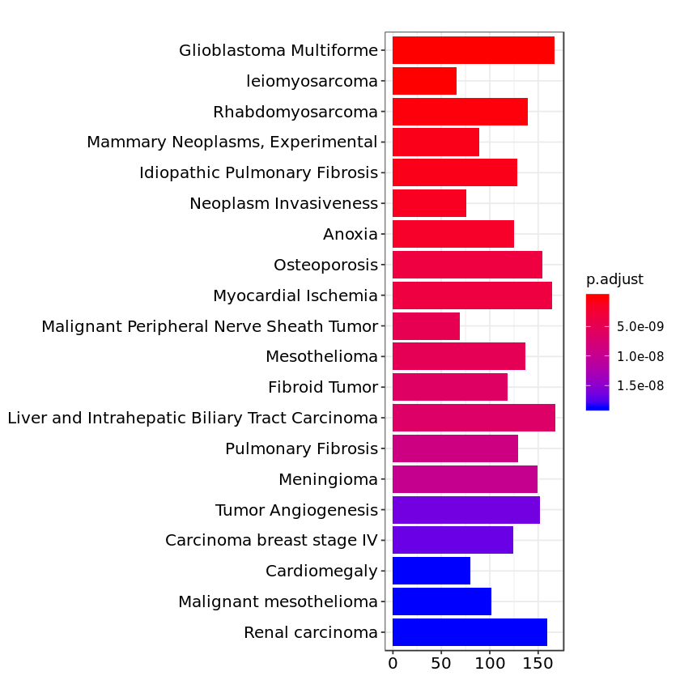

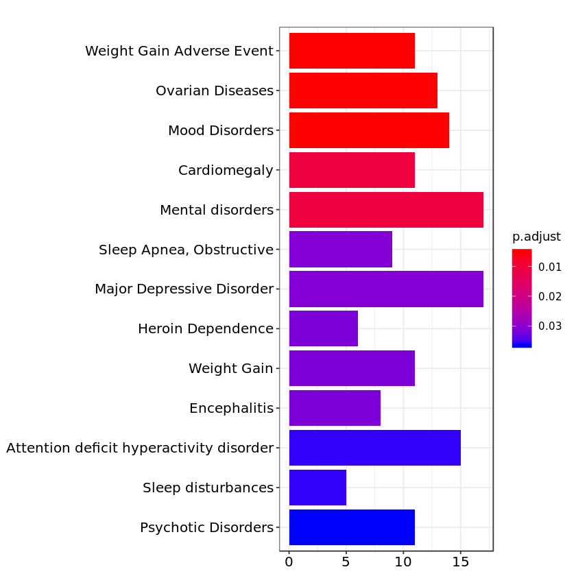

```r
par(mfrow=c(1,2))
barplot(edo, showCategory=20)
barplot(edo.subset, showCategory=20)
```

Here, we see an example of a dot plot. We only show the all-gene case because these plots depict the exact same finding as the bar plots, merely displaying them in a different manner that not only shows the proportion of genes but also the raw counts (shown through point radius).

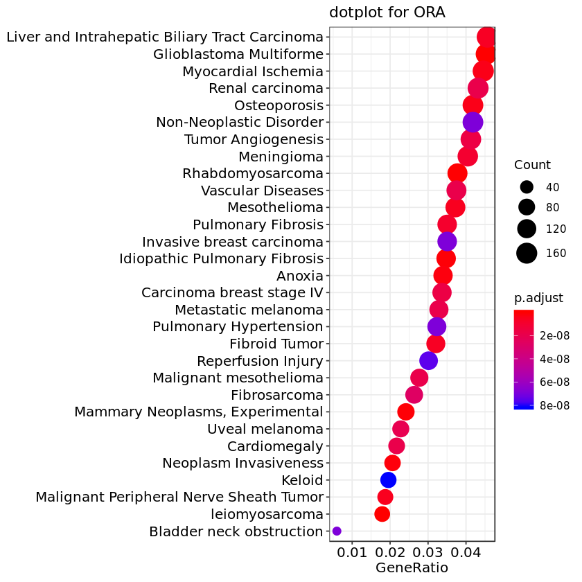

```r
p1 <- dotplot(edo, showCategory=30) + ggtitle("dotplot for ORA")
plot_grid(p1, ncol=1)
```

Next, we present a network map of these terms that show associations among the various disease states as determined by common genes that fall into multiple categories. This graphical display is useful for seeing how the significant genes work in concert with one another.

Here, we see an object lesson in why it is advantageous to look at subsets of genes: the network map of all significant genes is so dense that it is illegibile, but the map of the genes with the most extreme fold change is easy to interpret.

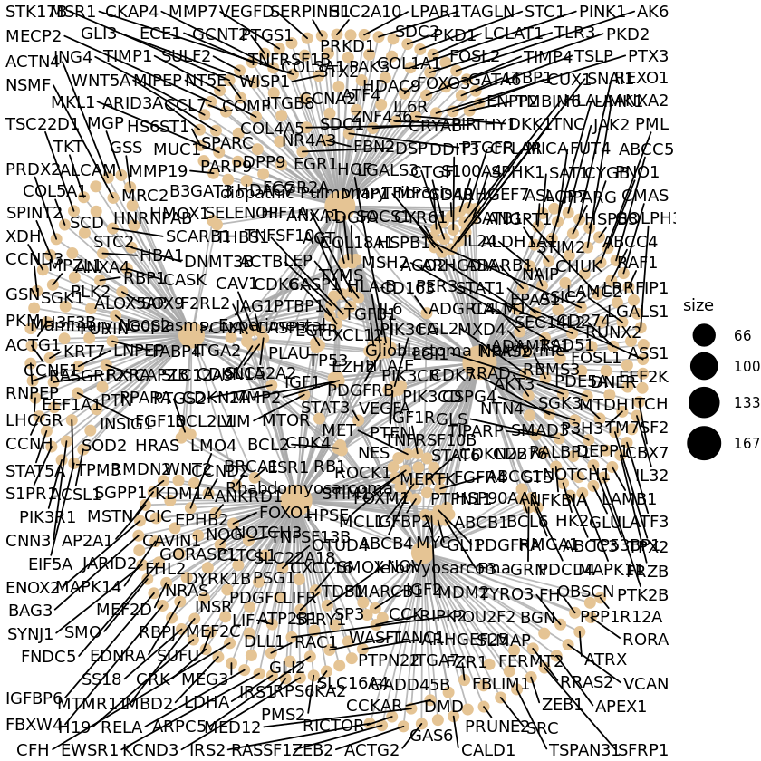

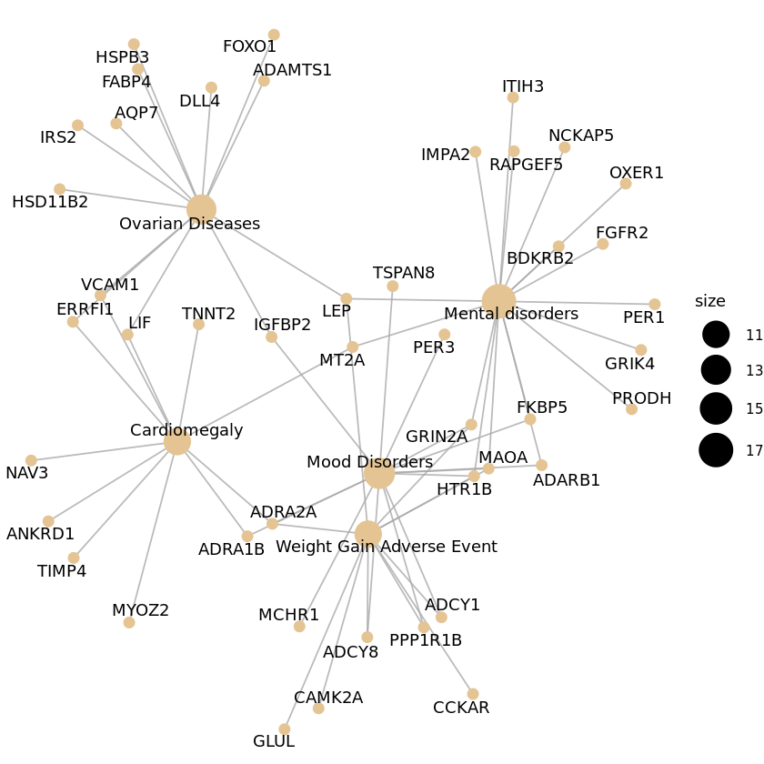

```r
edox <- setReadable(edo, 'org.Hs.eg.db', 'ENTREZID')
cnetplot(edox, foldChange=de.names)

edox.subset <- setReadable(edo.subset, 'org.Hs.eg.db', 'ENTREZID')
cnetplot(edox.subset, foldChange=de.names.subset)
```

Finally, we present the `upsetplot` - this type of diagram uses another method for showing the network association among genes and gene sets. It is a bit difficult to interpret, but does not run into problems with large numbers of genes.

Here, on the bottom left, we see the various gene sets and their size. To the right, we see dots showing groups of genes that fall into each category (the bars). When one bar has two or more dots, their dots are connected, and this connection means that the genes in that set are linked.

`upsetplot` is an excellent way to clearly display the intersection among many genes. It can be understood as analogous to a Venn diagram showing set overlaps, but a Venn diagram can only show at most 6 sets - the upsetplot does not have any such limitation.

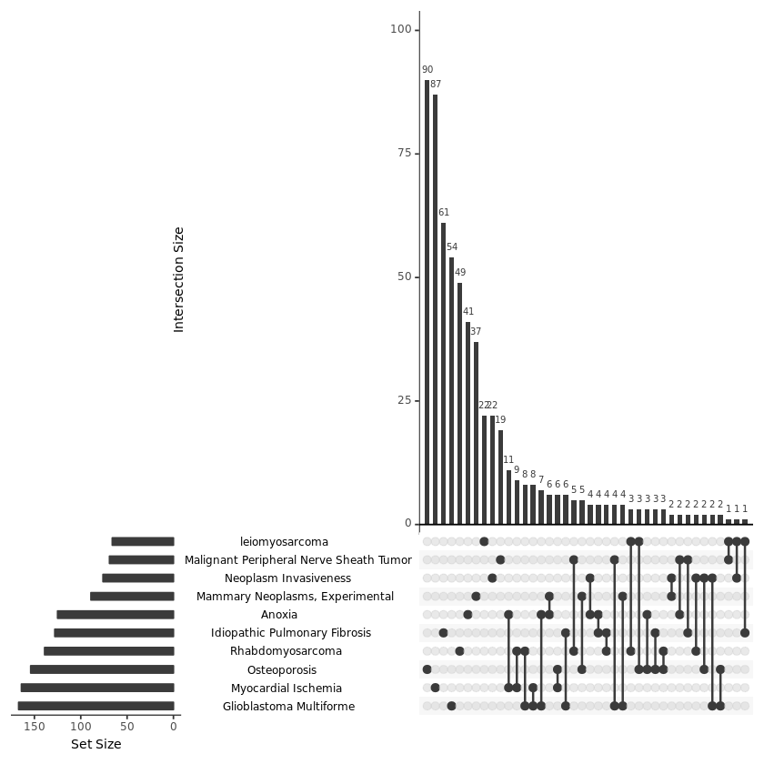

```r
upsetplot(edo)
```

# Conclusion

There are countless other ways to perform ontology analysis and represent the results thereof - far more than could be covered in any workshop. Users are encoraged to read through the documentation and vignettes of the packages discussed here today - there is plenty to discover within. We've covered the methods for mapping IDs and reshaping the data to accommodate numerous types of functions, and these principles broadly apply to the other methods.

If you use the results from an R analysis package in published research, you can find the proper citation for the software by typing `citation("pkgName")`, where you would substitute the name of the package for `pkgName`. Citing methods papers helps to support and reward the individuals who put time into developing free and open source software for genomic data analysis.

For any questions related to this material, or to submit a request for assistance in conducting your own ontology analysis, please contact us at cbc-help@brown.edu

# Appendix A

One easy-to-use GUI-based method for ontology analysis is [DAVID](https://david.ncifcrf.gov/) - this tool has sample datasets within it that can be used to preview its functions. It does not lend itself well for use in this workshop, due to the need to write to files and then input those files into DAVID, which would require some further explanation due to the Jupyter environment. Users should feel free to visit the site and use the example data, though.

# Hypothesis testing for count data

Generalized Linear Models (GLM) are a broad family of regression models, a small subset of which form the basis for differential expression and other hypothesis testing in genomics.

The components of a GLM are:

$$ g\left( E[y|x] \right) = \beta_0 + \beta_1 x_{1i} + \beta_2 x_{2i} + ... + \beta_p x_{pi} $$

- **Random component** specifies the conditional distribution for the response variable
  - doesn’t have to be normal
  - can be any distribution in the "exponential" family of distributions
- **Systematic component** specifies linear function of predictors (linear predictor)
- **Link** [denoted by g(.)] specifies the relationship between the expected value of the random component and the systematic component
  - can be linear or nonlinear

## Linear Regression as GLM

This is useful for log-transformed microarray data:

- **The model**: $y_i = E[y|x] + \epsilon_i = \beta_0 + \beta_1 x_{1i} + \beta_2 x_{2i} + ... + \beta_p x_{pi} + \epsilon_i$
- **Random component** of $y_i$ is normally distributed: $\epsilon_i \stackrel{iid}{\sim} N(0, \sigma_\epsilon^2)$
- **Systematic component** (linear predictor): $\beta_0 + \beta_1 x_{1i} + \beta_2 x_{2i} + ... + \beta_p x_{pi}$
- **Link function** here is the *identity link*: $g(E(y | x)) = E(y | x)$. We are modeling the mean directly, no transformation.

## Logistic Regression as GLM

This is useful for binary outcomes, e.g. Single Nucleotide Polymorphisms or somatic variants:

- **The model**: $$ Logit(P(x)) = log \left( \frac{P(x)}{1-P(x)} \right) = \beta_0 + \beta_1 x_{1i} + \beta_2 x_{2i} + ... + \beta_p x_{pi} $$
- **Random component**: $y_i$ follows a Binomial distribution (outcome is a binary variable)
- **Systematic component**: linear predictor $$ \beta_0 + \beta_1 x_{1i} + \beta_2 x_{2i} + ... + \beta_p x_{pi} $$
- **Link function**: *logit* (log of the odds that the event occurs) $$ g(P(x)) = logit(P(x)) = log\left( \frac{P(x)}{1-P(x)} \right) $$

## Log-linear GLM

This is useful for count data, like RNA-seq. It can:

```
+ account for differences in sequencing depth
+ guarantee non-negative expected number of counts
+ be used in conjunction with Poisson or Negative Binomial error models
```

- **The model** (`log(t_i)` is called an "offset" term): $$ log\left( E[y|x] \right) = \beta_0 + \beta_1 x_{1i} + \beta_2 x_{2i} + ... + \beta_p x_{pi} + log(t_i) $$

Without getting into details of Poisson or Negative Binomial error terms, they are just random distributions that happen to fit many count data well:

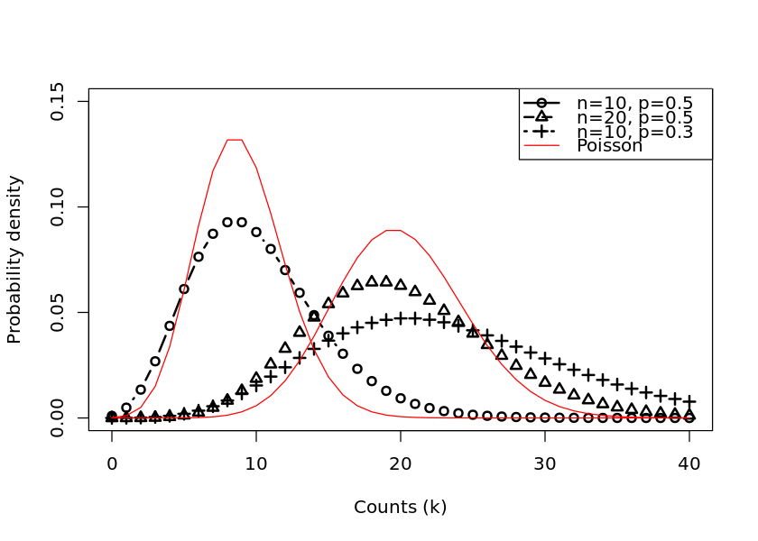

```r
options(repr.plot.height=5, repr.plot.width=7)
plot(x=0:40, y=dnbinom(0:40, size=10, prob=0.5),
     type="b", lwd=2, ylim=c(0, 0.15),
     xlab="Counts (k)", ylab="Probability density")
lines(x=0:40, y=dnbinom(0:40, size=20, prob=0.5),
      type="b", lwd=2, lty=2, pch=2)
lines(x=0:40, y=dnbinom(0:40, size=10, prob=0.3),
      type="b", lwd=2, lty=3, pch=3)
lines(x=0:40, y=dpois(0:40, lambda=9), col="red")
lines(x=0:40, y=dpois(0:40, lambda=20), col="red")
legend("topright", lwd=c(2,2,2,1), lty=c(1:3,1), pch=c(1:3,-1), col=c(rep("black", 3), "red"),
       legend=c("n=10, p=0.5", "n=20, p=0.5", "n=10, p=0.3", "Poisson"))
```

**Figure**: Two Poisson distributions (shown as red lines), and three Negative Binomial (NB) distributions selected for having similarly located peak probabilities. Note the greater dispersion and the tunability of NB distribution. Also note that probabilities are only non-zero defined for integer values.

# Small samples, large samples, and the Central Limit Theorem

## What is a *sampling distribution*?

It is the distribution of a statistic for many samples taken from one population.

1. Take a sample from a population
2. Calculate the sample statistic (e.g. mean)
3. Repeat.
4. The values from (2) form a sampling distribution.
5. The standard deviation of the sampling distribution is the *standard error*
6. Question: how is this different from a population distribution?

## Example: population and sampling distributions

We observe 100 counts from a Poisson distribution ($\lambda = 2$).

- Question: is this a population or a sampling distribution?

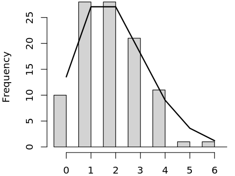

```r
options(repr.plot.height=3, repr.plot.width=3)
set.seed(1)
onesample=rpois(100, lambda=2)
xdens = seq(min(onesample), max(onesample), by=1)
ydens = length(onesample) * dpois(xdens, lambda=2)
par(mar=c(2, 4, 0.1, 0.1))
options(repr.plot.width=4, repr.plot.height=3)
res=hist(onesample, main="", prob=FALSE, col="lightgrey", xlab="", ylim=c(0, max(ydens)),
     breaks=seq(-0.5, round(max(onesample))+0.5, by=0.5))
lines(xdens, ydens, lw=2)
```

We calculate the *mean* of those 100 counts, and do the same for 1,000 more samples of 100:

- Question: is this a population or a sampling distribution?

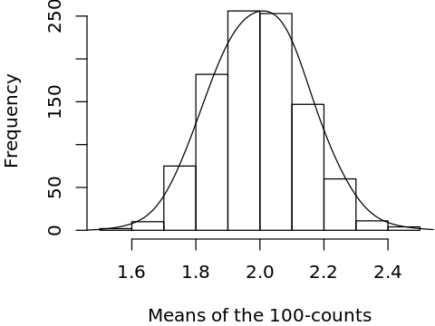

```r
set.seed(1)
samplingdistr=replicate(1000, mean(rpois(100, lambda=2)))
par(mar=c(4, 4, 0.1, 0.1))
res=hist(samplingdistr, xlab="Means of the 100-counts", main="")
dy=density(samplingdistr, adjust=2)
## Note this next step is just an empirical way to put the density line approximately the same scale as the histogram:
dy$y = dy$y / max(dy$y) * max(res$counts)
lines(dy)
```

## Central Limit Theorem

The "CLT" relates the sampling distribution (of means) to the population distribution.

1. Mean of the population ($\mu$) and of the sampling distribution ($\bar{X}$) are identical
2. Standard deviation of the population ($\sigma$) is related to the standard deviation of the distribution of sample means (*Standard Error* or *SE*) by: $$ SE = \sigma / \sqrt{n} $$
3. For large n, the shape of the sampling distribution of means becomes normal

### CLT 1: equal means

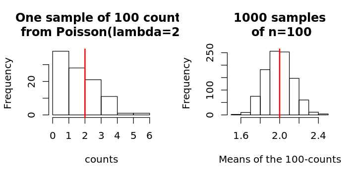

```r
options(repr.plot.width=6, repr.plot.height=3)
par(mfrow=c(1,2))
hist(onesample, main="One sample of 100 counts\n from Poisson(lambda=2)", xlab="counts")
abline(v=2, col="red", lw=2)
res=hist(samplingdistr, xlab="Means of the 100-counts", main="1000 samples\n of n=100")
abline(v=2, col="red", lw=2)
```

- Distributions are different, but means are the same

### CLT 2: Standard Error

Standard deviation of the sampling distribution is $SE = \sigma / \sqrt{n}$:

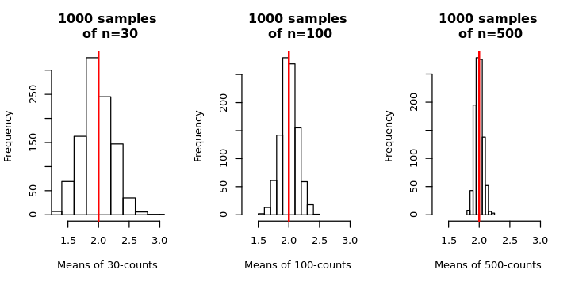

```r
options(repr.plot.width=6, repr.plot.height=3)
par(mfrow=c(1,3))
hist(replicate(1000, mean(rpois(30, lambda=2))), xlim=c(1.3, 3),
     xlab="Means of 30-counts", main="1000 samples\n of n=30")
abline(v=2, col="red", lw=2)
hist(replicate(1000, mean(rpois(100, lambda=2))), xlim=c(1.3, 3),
     xlab="Means of 100-counts", main="1000 samples\n of n=100")
abline(v=2, col="red", lw=2)
hist(replicate(1000, mean(rpois(500, lambda=2))), xlim=c(1.3, 3),
     xlab="Means of 500-counts", main="1000 samples\n of n=500")
abline(v=2, col="red", lw=2)
```

### CLT 3: large samples

- The distribution of means of large samples is normal.
  - for large enough n, the population distribution doesn't matter. How large?
  - n < 30: population is normal or close to it
  - n >= 30: skew and outliers are OK
  - n > 500: even extreme population distributions

*Example*: an extremely skewed (log-normal) distribution:

[figure not shown]

```r
options(repr.plot.width=6, repr.plot.height=3)
par(mfrow=c(1,3))
set.seed(5)
onesample=rlnorm(n=100, sdlog=1.5)
hist(onesample, main="100 observations\n from lognormal pop'n", xlab="counts")
sampling30=replicate(1000, mean(rlnorm(n=30, sdlog=1.5)))
hist(sampling30, xlab="Means of the 100 obs.", main="1000 samples\n of n=30")
sampling1000=replicate(1000, mean(rlnorm(n=1000, sdlog=1.5)))
hist(sampling1000, xlab="Means of the 1000 obs.", main="1000 samples\n of n=1000")
```

# Correcting for batch effects

Suppose we did not know that there were different cell lines involved in the experiment, only that there was treatment with dexamethasone. The cell line effect on the counts then would represent some hidden and unwanted variation that might be affecting many or all of the genes in the dataset. We can use statistical methods designed for RNA-seq from the [sva](http://www.bioconductor.org/packages/Gviz) package to detect such groupings of the samples, and then we can add these to the *DESeqDataSet* design, in order to account for them. The *SVA* package uses the term *surrogate variables* for the estimated variables that we want to account for in our analysis. Another package for detecting hidden batches is the RUVSeq package, with the acronym "Remove Unwanted Variation".

```r
suppressPackageStartupMessages(library(sva))
```

Below we obtain a matrix of normalized counts for which the average count across samples is larger than 1. As we described above, we are trying to recover any hidden batch effects, supposing that we do not know the cell line information. So we use a full model matrix with the *dex* variable, and a reduced, or null, model matrix with only an intercept term. Finally we specify that we want to estimate 2 surrogate variables. For more information read the manual page for the *svaseq* function by typing `?svaseq`.

```r
dat  <- counts(dds, normalized = TRUE)
idx  <- rowMeans(dat) > 1
dat  <- dat[idx, ]
mod  <- model.matrix(~ dex, colData(dds))
mod0 <- model.matrix(~   1, colData(dds))
svseq <- svaseq(dat, mod, mod0, n.sv = 2)
```

```
Number of significant surrogate variables is:  2
Iteration (out of 5 ):1  2  3  4  5
```

```r
svseq$sv
```

| 0.2481108 | -0.52600157 |
| --- | --- |
| 0.2629867 | -0.58115433 |
| 0.1502704 | 0.27428267 |
| 0.2023800 | 0.38419545 |
| -0.6086586 | -0.07854931 |
| -0.6101210 | -0.02923693 |
| 0.1788509 | 0.25708985 |
| 0.1761807 | 0.29937417 |

Because we actually do know the cell lines, we can see how well the SVA method did at recovering these variables (figure below).

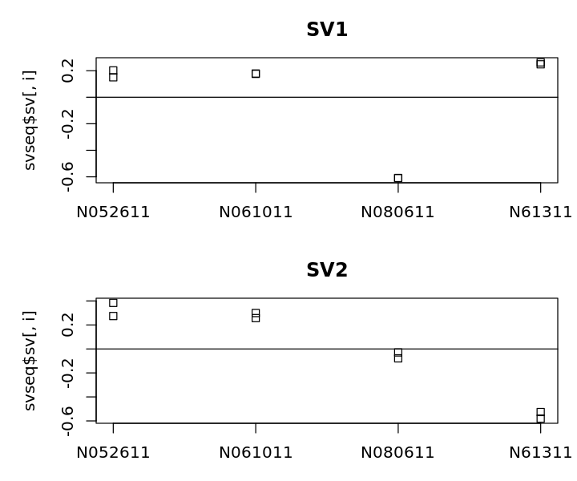

```r
options(repr.plot.height=5)
par(mfrow = c(2, 1), mar = c(3,5,3,1))
for (i in 1:2) {
  stripchart(svseq$sv[, i] ~ dds$cell, vertical = TRUE, main = paste0("SV", i))
  abline(h = 0)
 }
```

[figure not shown]

**Surrogate variables 1 and 2 plotted over cell line.** Here, we know the hidden source of variation (cell line), and therefore can see how the SVA procedure is able to identify a source of variation which is correlated with cell line.

Finally, in order to use SVA to remove any effect on the counts from our surrogate variables, we simply add these two surrogate variables as columns to the *DESeqDataSet* and then add them to the design:

```r
ddssva <- dds
ddssva$SV1 <- svseq$sv[,1]
ddssva$SV2 <- svseq$sv[,2]
design(ddssva) <- ~ SV1 + SV2 + dex
```

We could then produce results controlling for surrogate variables by running *DESeq* with the new design:

```r
DESeq(ddssva)
```

```
found already estimated dispersions, replacing these
```

```
class: DESeqDataSet
dim: 64102 8
metadata(2): '' version
assays(4): counts mu H cooks
rownames(64102): ENSG00000000003 ENSG00000000005 ... LRG_98 LRG_99
rowData names(30): baseMean baseVar ... deviance maxCooks
colnames(8): SRR1039508 SRR1039509 ... SRR1039520 SRR1039521
colData names(12): SampleName cell ... SV1 SV2
```

## Gene clustering

In the sample distance heatmap made in our previous workshop, the dendrogram at the side shows us a hierarchical clustering of the samples. Such a clustering can also be performed for the genes. Since the clustering is only relevant for genes that actually carry a signal, one usually would only cluster a subset of the most highly variable genes. Here, for demonstration, let us select the 20 genes with the highest variance across samples. We will work with the *rlog*-transformed counts:

```r
rld <- rlog(dds, blind=FALSE, fitType="mean")
suppressPackageStartupMessages(library(genefilter))
topVarGenes <- head(order(rowVars(assay(rld)), decreasing = TRUE), 20)
```

The heatmap becomes more interesting if we do not look at absolute expression strength but rather at the amount by which each gene deviates in a specific sample from the gene's average across all samples. Hence, we center each genes' values across samples, and plot a heatmap (figure below). We provide a *data.frame* that instructs the *pheatmap* function how to label the columns.

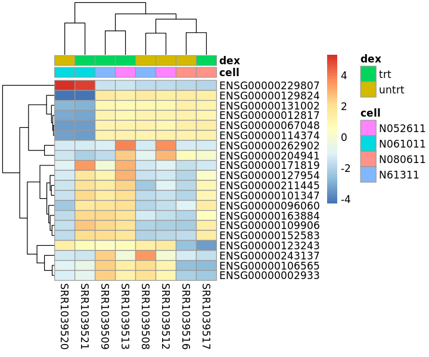

```r
library(pheatmap)
mat  <- assay(rld)[ topVarGenes, ]
mat  <- mat - rowMeans(mat)
anno <- as.data.frame(colData(rld)[, c("cell","dex")])
pheatmap(mat, annotation_col = anno)
```

**Heatmap of relative rlog-transformed values across samples.** Treatment status and cell line information are shown with colored bars at the top of the heatmap. Blocks of genes that covary across patients. Note that a set of genes at the top of the heatmap are separating the N061011 cell line from the others. In the center of the heatmap, we see a set of genes for which the dexamethasone treated samples have higher gene expression.

## Stratified random sampling

- done with population sampling

[figure not shown]

- divides population into more homogeneous subpopulations
  - during design, strata are normally with predetermined probabilities

## Stratification in analysis

- experimental blocks and population strata could either be treated as factors or strata for analysis
  - stratification is necessary when you think a factor in a linear model is inadequate to capture differences between nuisance strata
- observations are:
  - divided into strata
  - strata are analyzed independently
  - results are then averaged across strata